# Quality Checks

### Exploring the relationship between ASV and read count.

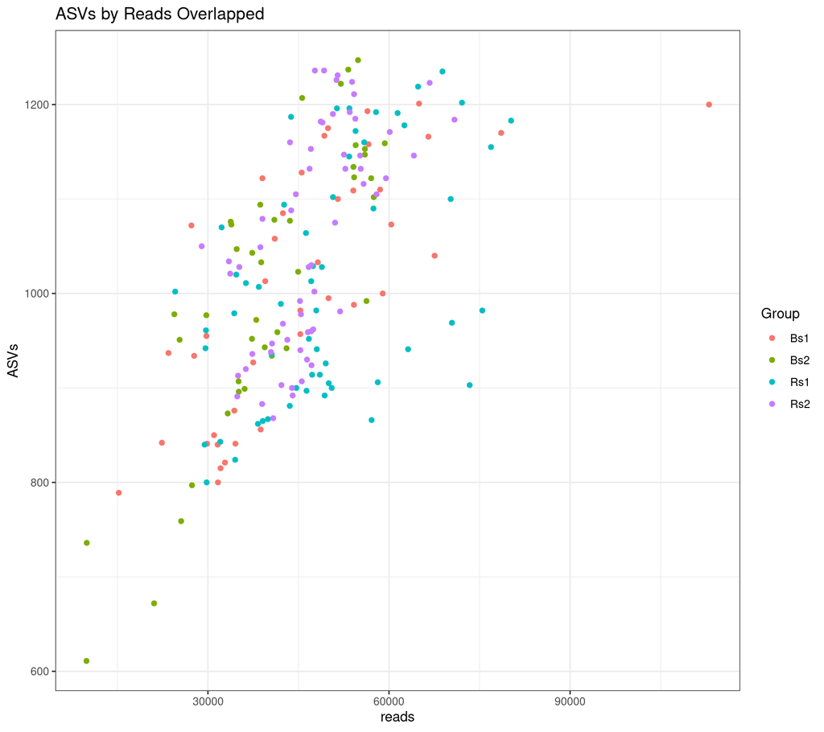

Scatter plot of ASVs by Reads colored by Group indicates that all samples mix well and are fairly well sampled.

- *What about coloring by the other factors, Temp and Replicate? Do any new patterns emerge?*

## Taxonomic Assignment QA/QC

Plotting the amplicon length distribution

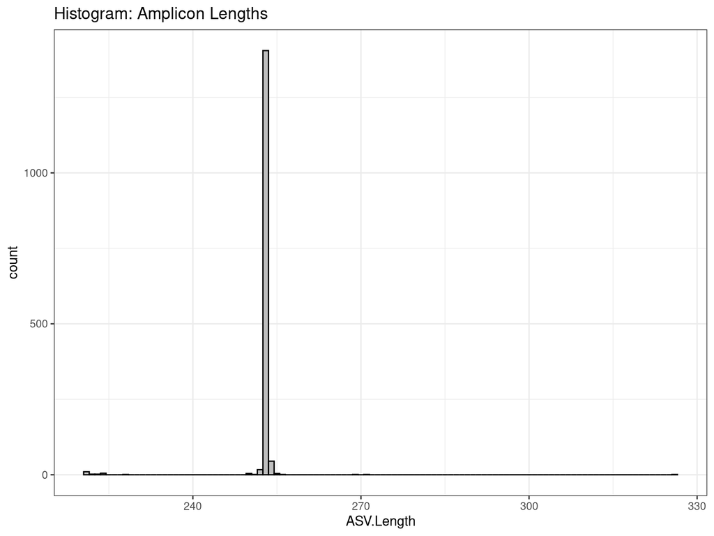

```r
df = data.frame(names=names(refseq(ps)), ASV.Length = Biostrings::width(refseq(ps)))
ggplot(df, aes(x=ASV.Length)) + geom_histogram(binwidth=1, color='black', fill='grey') +
  theme_bw() + labs(title="Histogram: Amplicon Lengths")
```

Are there trends in the fraction of **reads** that can be assigned to taxonomic level by experimental variables?

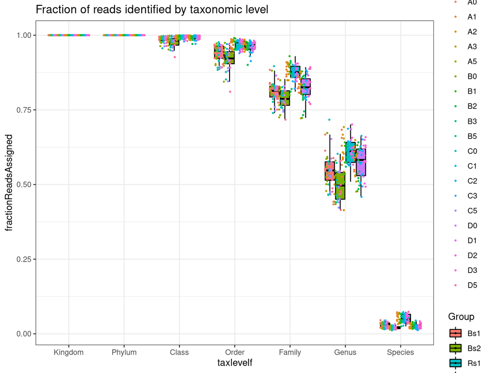

```r
readsPerSample = rowSums(otu_table(ps))
fractionReadsAssigned = sapply(colnames(tax_table(ps)), function(x){
  rowSums(otu_table(ps)[, !is.na(tax_table(ps))[,x]]) / readsPerSample
})

fractionReadsAssigned = data.frame(SampleID = rownames(fractionReadsAssigned), fractionReadsAssigned)
fractionReadsAssigned.L = pivot_longer(fractionReadsAssigned,
    cols=colnames(tax_table(ps)), names_to="taxlevel", values_to="fractionReadsAssigned")
fractionReadsAssigned.L = data.frame(fractionReadsAssigned.L, sample_data(ps)[fractionReadsAssigned.L$SampleID,])

fractionReadsAssigned.L$taxlevelf = factor(fractionReadsAssigned.L$taxlevel, levels=c("Kingdom","Phylum","Class","Order","Family","Genus","Species"))

# Boxplot, fraction assigned by SampleType
ggplot(fractionReadsAssigned.L, aes(y = fractionReadsAssigned, x = taxlevelf, fill=Group, color=Replicate)) +
  theme_bw() +
  geom_boxplot(color='black', outlier.shape=NA) +
  ggtitle("Fraction of reads identified by taxonomic level") +
  geom_point(position=position_jitterdodge(jitter.width=0, jitter.height=0), size=.5)
```

Are there trends in the fraction of **ASVs** that can be assigned to taxonomic level by experimental variables?

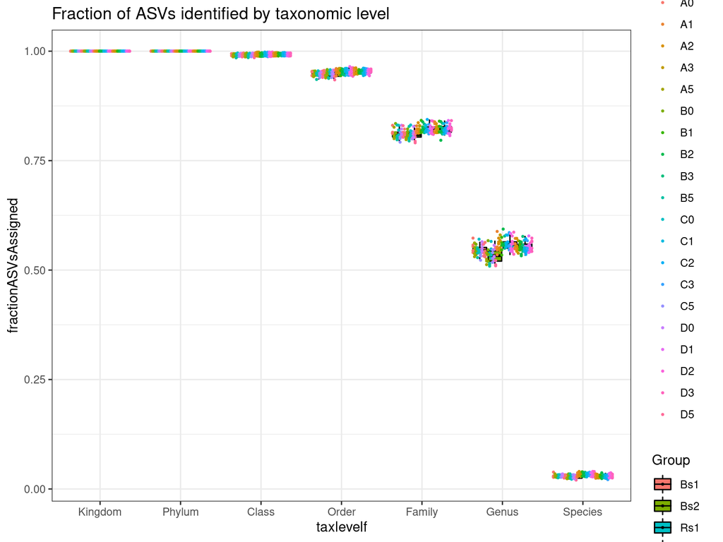

Genus level:

The statistics in this plot are calculated by merging taxa at the “Genus” rank with the tax_glom() function. This strategy works by summing reads from all ASVs with the same assignment at the specified taxonomic level. The ASV with the highest read count is selected as the representative for the agglomerated set. ASV with NA are removed.

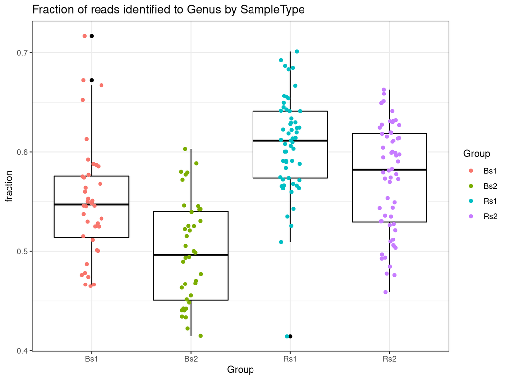

Top 20 most **abundant** ASVs and their taxonomic assignment:

|  | Prevalence | TotalAbundance | Kingdom | Phylum | Class | Order | Family | Genus | Species |
| --- | --- | --- | --- | --- | --- | --- | --- | --- | --- |
| ASV1 | 197 | 170379 | Bacteria | Desulfobacterota | Syntrophobacteria | Syntrophobacterales | Syntrophobacteraceae | Syntrophobacter | NA |
| ASV2 | 185 | 88391 | Bacteria | Cyanobacteria | Cyanobacteriia | Chloroplast | NA | NA | NA |
| ASV3 | 197 | 88231 | Bacteria | Firmicutes | Bacilli | Bacillales | Planococcaceae | Paenisporosarcina | NA |
| ASV4 | 197 | 51311 | Bacteria | Myxococcota | bacteriap25 | NA | NA | NA | NA |
| ASV5 | 195 | 47771 | Bacteria | Firmicutes | Bacilli | Bacillales | Planococcaceae | Paenisporosarcina | NA |
| ASV6 | 197 | 46828 | Bacteria | Firmicutes | Clostridia | Clostridiales | Clostridiaceae | Clostridium sensu stricto 1 | NA |
| ASV7 | 179 | 44661 | Bacteria | Bacteroidota | Bacteroidia | Chitinophagales | Chitinophagaceae | Flavisolibacter | NA |
| ASV8 | 148 | 43180 | Bacteria | Proteobacteria | Alphaproteobacteria | Rickettsiales | Mitochondria | NA | NA |
| ASV9 | 196 | 42622 | Bacteria | Firmicutes | Bacilli | Bacillales | Bacillaceae | Bacillus | NA |
| ASV10 | 196 | 41505 | Bacteria | Bacteroidota | Ignavibacteria | Ignavibacteriales | Ignavibacteriaceae | Ignavibacterium | NA |
| ASV11 | 166 | 38181 | Bacteria | Proteobacteria | Alphaproteobacteria | Rickettsiales | Mitochondria | NA | NA |
| ASV12 | 106 | 38181 | Bacteria | Proteobacteria | Alphaproteobacteria | Rickettsiales | Mitochondria | NA | NA |
| ASV13 | 166 | 37665 | Bacteria | Bacteroidota | Bacteroidia | Chitinophagales | Chitinophagaceae | NA | NA |
| ASV14 | 197 | 37063 | Bacteria | Desulfobacterota | Desulfuromonadia | Geobacterales | Geobacteraceae | Citrifermentans | NA |
| ASV15 | 187 | 35443 | Bacteria | Bacteroidota | Bacteroidia | Chitinophagales | Chitinophagaceae | NA | NA |
| ASV16 | 195 | 34794 | Bacteria | Actinobacteriota | Actinobacteria | Streptomycetales | Streptomycetaceae | Streptomyces | NA |
| ASV17 | 197 | 33384 | Bacteria | Bacteroidota | Bacteroidia | Chitinophagales | Chitinophagaceae | Flavisolibacter | NA |
| ASV18 | 197 | 33231 | Bacteria | Desulfobacterota | Desulfuromonadia | Geobacterales | Geobacteraceae | Geobacter | NA |
| ASV19 | 196 | 32304 | Bacteria | Firmicutes | Clostridia | Clostridiales | Clostridiaceae | Clostridium sensu stricto 1 | NA |
| ASV20 | 196 | 28475 | Bacteria | Actinobacteriota | Actinobacteria | Micrococcales | Micrococcaceae | Pseudarthrobacter | NA |

Top 20 most **prevalent** ASVs and their taxonomic assignment:

|  | Prevalence | TotalAbundance | Kingdom | Phylum | Class | Order | Family | Genus | Species |
| --- | --- | --- | --- | --- | --- | --- | --- | --- | --- |
| ASV1 | 197 | 170379 | Bacteria | Desulfobacterota | Syntrophobacteria | Syntrophobacterales | Syntrophobacteraceae | Syntrophobacter | NA |
| ASV3 | 197 | 88231 | Bacteria | Firmicutes | Bacilli | Bacillales | Planococcaceae | Paenisporosarcina | NA |
| ASV4 | 197 | 51311 | Bacteria | Myxococcota | bacteriap25 | NA | NA | NA | NA |
| ASV6 | 197 | 46828 | Bacteria | Firmicutes | Clostridia | Clostridiales | Clostridiaceae | Clostridium sensu stricto 1 | NA |
| ASV14 | 197 | 37063 | Bacteria | Desulfobacterota | Desulfuromonadia | Geobacterales | Geobacteraceae | Citrifermentans | NA |
| ASV17 | 197 | 33384 | Bacteria | Bacteroidota | Bacteroidia | Chitinophagales | Chitinophagaceae | Flavisolibacter | NA |
| ASV18 | 197 | 33231 | Bacteria | Desulfobacterota | Desulfuromonadia | Geobacterales | Geobacteraceae | Geobacter | NA |
| ASV22 | 197 | 28145 | Bacteria | Cyanobacteria | Cyanobacteriia | Chloroplast | NA | NA | NA |
| ASV43 | 197 | 21056 | Bacteria | Nitrospirota | Thermodesulfovibrionia | NA | NA | NA | NA |
| ASV49 | 197 | 20157 | Bacteria | Desulfobacterota | Desulfobacteria | Desulfobacterales | Desulfosarcinaceae | Desulfatirhabdium | NA |
| ASV50 | 197 | 20143 | Bacteria | Proteobacteria | Alphaproteobacteria | Rickettsiales | Mitochondria | NA | NA |
| ASV52 | 197 | 19850 | Bacteria | Bacteroidota | Ignavibacteria | Ignavibacteriales | Ignavibacteriaceae | Ignavibacterium | NA |
| ASV53 | 197 | 19751 | Bacteria | Firmicutes | Clostridia | Clostridiales | Clostridiaceae | Clostridium sensu stricto 13 | NA |
| ASV59 | 197 | 19032 | Bacteria | Proteobacteria | Gammaproteobacteria | Burkholderiales | Comamonadaceae | Ramlibacter | NA |
| ASV61 | 197 | 18837 | Bacteria | Firmicutes | Bacilli | Bacillales | Planococcaceae | Planococcus | NA |
| ASV63 | 197 | 18705 | Bacteria | Desulfobacterota | Desulfuromonadia | Geobacterales | Geobacteraceae | NA | NA |
| ASV67 | 197 | 18273 | Bacteria | Desulfobacterota | Desulfuromonadia | Geobacterales | Geobacteraceae | NA | NA |
| ASV70 | 197 | 17907 | Bacteria | RCP2-54 | NA | NA | NA | NA | NA |
| ASV83 | 197 | 16694 | Bacteria | Desulfobacterota | Desulfuromonadia | Geobacterales | Geobacteraceae | Citrifermentans | NA |
| ASV92 | 197 | 15733 | Bacteria | Desulfobacterota | Syntrophobacteria | Syntrophobacterales | Syntrophobacteraceae | Desulfovirga | NA |

Save object

```r
dir.create("rdata_objects", showWarnings = FALSE)
save(ps, file=file.path("rdata_objects", "analysis.Rdata"))
```

# Cleanup

Get next Rmd

```r
download.file("https://raw.githubusercontent.com/ucdavis-bioinformatics-training/2021-May-Microbial-Community-Analysis/master/data_analysis/mca_part3.Rmd", "/mnt/c/Users/noahs/Desktop/2021-mca_workshop/03-DADA2/mca_part3.Rmd")
```